Cornell Systems Engineering · M.Eng. 2026

# Six MEng Projects: big-data & AI for urban and environmental systems

Build big-data and AI systems to measure and track outcomes across urban and environmental systems — air quality, congestion pricing, mobility networks, and disaster resilience.

Looks R-heavy? It isn't. Whatever fits the problem — **React, Python, R, SQL, cloud**. You'll **vibecode** across all of it.

New to coding? Welcome. Come ready to self-learn — and co-enroll in **SYSEN 5300** (Fall · R foundation) or **SYSEN 5381** (Spring) to skill up.

🚗MOVESAI

AI-Powered Emissions Reporting Systems with MOVESAI

Machine Learning · Dashboards · Emissions

SYSEN 5900-648

🏙️Urban Air

Urban Air Quality and Traffic Data Systems with CIVIC

Air Quality · Transportation · Causal Inference

SYSEN 5900-662

🏘️Soc. Infra

Social Infrastructure & Emergency Mobility

GIS · Urban Resilience · Emergency Management

SYSEN 5900-663

🚲Bikeshare

Bikeshare Network Analytics

Networks · Big Data · Mobility

SYSEN 5900-664

🌳Fault Tree

Agentic Fault Tree Analysis with FaultDB

Reliability · Safety · Agentic AI

SYSEN 5900-665

☢️SAFECAST

Open-Source Radiation Monitoring with SAFECAST

Sensors · Open Data · Crisis Response

SYSEN 5900-666

**Recruiting teams now.** Distance-learning & on-campus students both welcome — each project ships a report plus a working tool. Each project is its own **SYSEN 5900** section; form a team and register for the section shown on its card. Full details → **timothyfraser.com**

SYSEN 5900-648MOVESAI

Machine Learning · Dashboards · Emissions

🚗

## AI-Powered Emissions Reporting Systems with MOVESAI

Surrogate→Dashboard→Report

Can AI reproduce a heavyweight EPA emissions model fast enough for any city to use online?

Build AI and ML systems that reproduce EPA's MOVES emissions simulator and serve it through fast APIs and dashboards — so cities can estimate and report transportation emissions online without running the full model. Work spans machine learning, API design, dashboards, and the report that ships with it.

Register for **SYSEN 5900-648** · short title **MOVESAI**

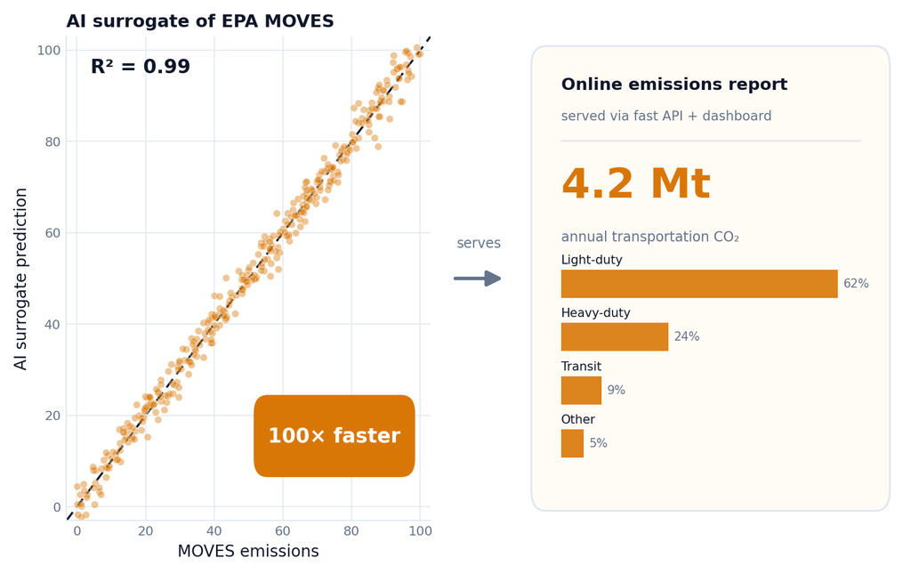

SYSEN 5900-662Urban Air

Air Quality · Transportation · Causal Inference

🏙️

## Urban Air Quality and Traffic Data Systems with CIVIC

Data→Integration→Report

When a city charges drivers to enter its core, does the air actually get cleaner — and who benefits?

Build the data systems behind CIVIC: integrate air quality, transit, and traffic data from cities like NYC, London, and Stockholm, then use causal inference to measure how policies shift pollution and travel. Work spans data engineering, panel databases, statistics, and communicating results to a policy audience.

Register for **SYSEN 5900-662** · short title **Urban Air**

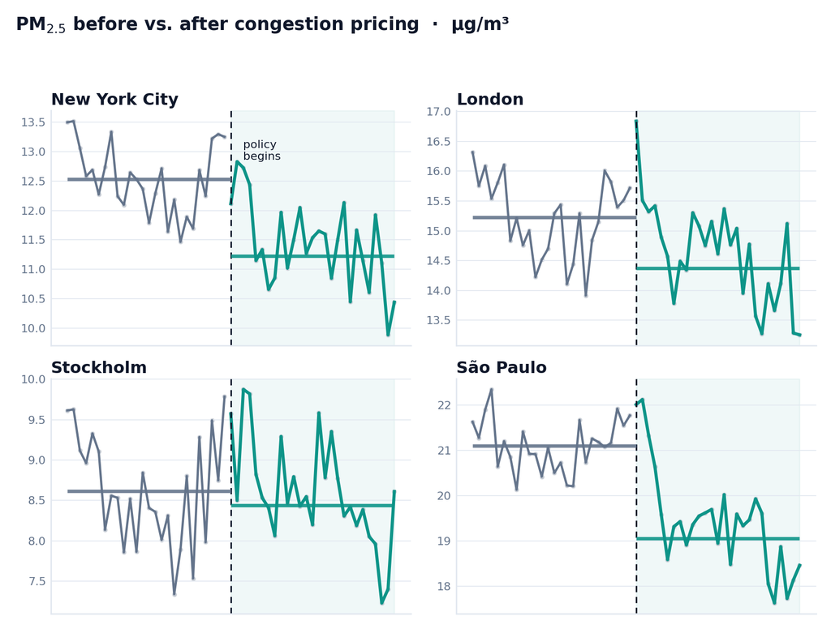

SYSEN 5900-663Soc. Infra

GIS · Urban Resilience · Emergency Management

🏘️

## Social Infrastructure & Emergency Mobility

Data pipeline→Scoring→Report

Does where your neighbors gather predict how well your city survives a disaster?

Build spatial pipelines that score civic spaces — parks, libraries, places of worship — across dozens of US cities, then link those scores to evacuation behavior and hazard exposure using mobility data. Work spans GIS, spatial statistics, a dashboard and API, and a report on community resilience.

Register for **SYSEN 5900-663** · short title **Soc. Infra**

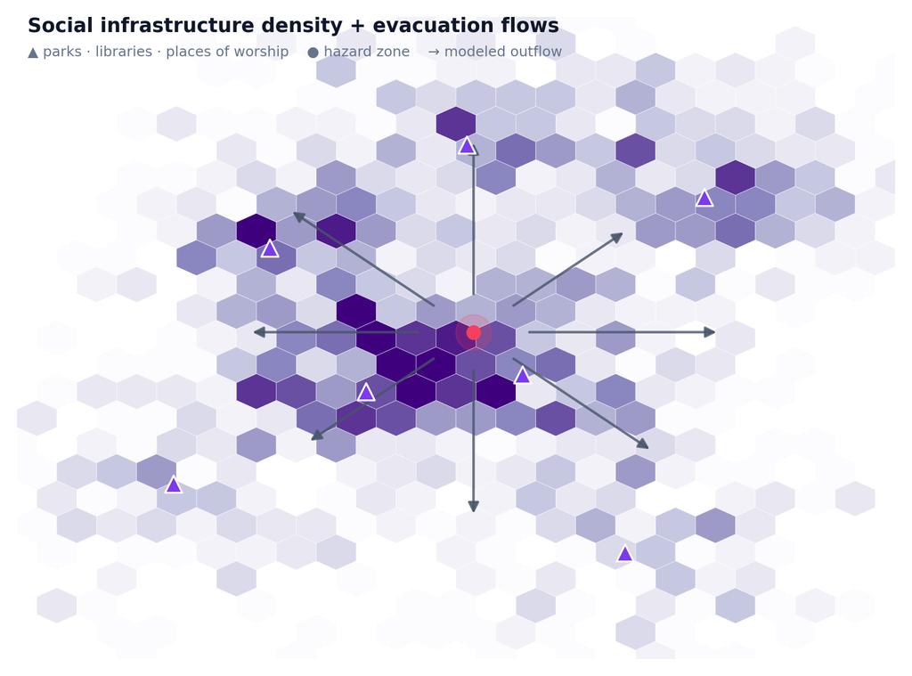

SYSEN 5900-664Bikeshare

Networks · Big Data · Mobility

🚲

## Bikeshare Network Analytics

Fetch→Unify→Model

What patterns emerge when we compare how riders move across every major US bikeshare system?

Fetch and unify millions of trip records from every major US bikeshare system into one analysis-ready database with a shared schema, then model the resulting mobility networks to study ridership, equity, and behavior no single city's data can reveal alone. Work spans network science, large-scale data fetching, and database design.

Register for **SYSEN 5900-664** · short title **Bikeshare**

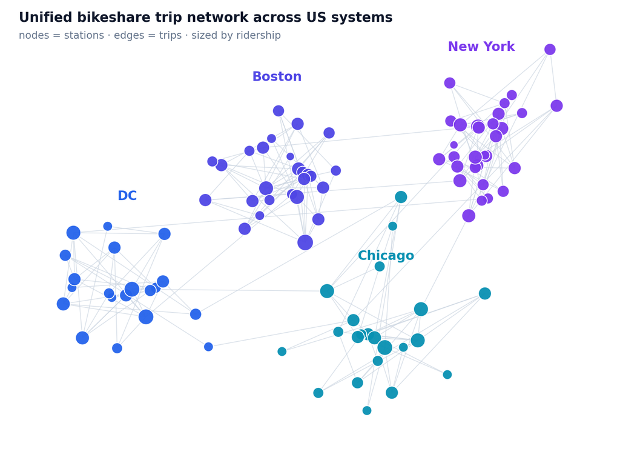

SYSEN 5900-665Fault Tree

Reliability · Safety · Agentic AI

🌳

## Agentic Fault Tree Analysis with FaultDB

PoC→Alpha→Beta

What is the probability that this system fails — and which components matter most?

Extend FaultDB — a browser platform pairing an R analysis engine with a React diagram editor — and add agentic AI workflows that help users build fault and attack trees, run cut-set analysis, and interpret results. Work spans LLM agent design, reliability modeling, interactive front-ends, and the API behind them.

Register for **SYSEN 5900-665** · short title **Fault Tree**

[figure not shown]

SYSEN 5900-666SAFECAST

Sensors · Open Data · Crisis Response

☢️

## Open-Source Radiation Monitoring with SAFECAST

Sensors→Dashboard→AI

After a nuclear disaster, can an open citizen-run sensor network tell people what's safe — clearly, and in real time?

SAFECAST is a Tokyo-based nonprofit running the largest open dataset of background-radiation measurements — crowdsourced after the 2011 Fukushima disaster and now mapping Fukushima, Ukraine, and cities worldwide. Your team will help build out their dashboard systems and AI integration so a global citizen-sensor network can communicate accurate radiation information to the public when it matters most. Work spans databases, sensors, APIs, React, dashboards, and data visualization.

Register for **SYSEN 5900-666** · short title **SAFECAST**

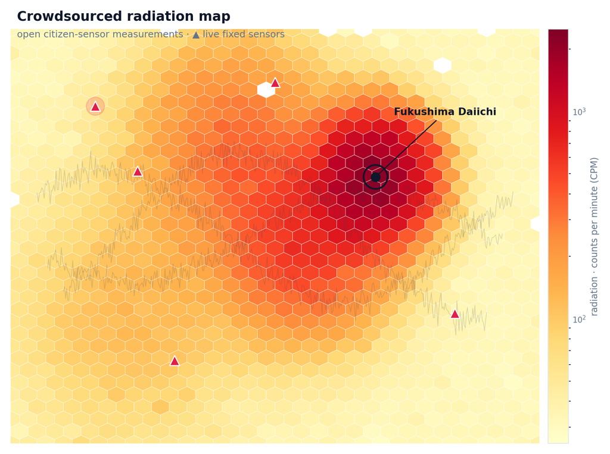